# Practice of Data Science Final Project: Charlottesville Fire Incident Duration

## Question and Background Information

### Question

> Based on location, origin, time and other data about a fire, can our model predict the amount of time it will take the Charlottesville, VA firefighters to put the fire out?

This question is important to ask because a model can help fire departments predict how long a fire will take to put out at any given address, time, or origin of the fire. Ideally, if a department gets a call about a fire, and they know the address, time, origin of the fire, etc, they can predict within a reasonable range how long it will take for the firefighters and resources to be back to the station to be ready to go fight the next fire. Helping fire departments understand how many resources they need and how they can spread out these resources can assist in making fire response more equitable regardless of area.

### Background Information

This data was collected by the City of Charlottesville, VA, originally published in August of 2020 and later updated in September 2020. The fire incidents reported occurred from 04/2002-9/2019. We need to consider a few fire response variables as explained in [a 2013 study thattalks about Data Model Development for Fire Related Extreme Events](https://www.jstor.org/stable/43825940).

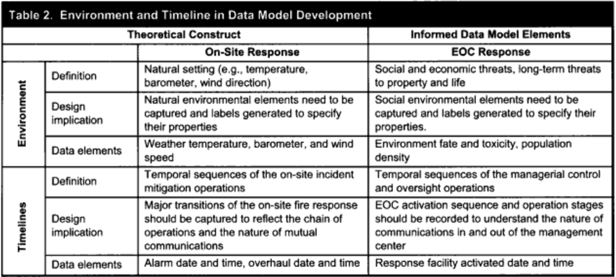

## Exploratory Data Analysis

We first looked at the distribution of our target variable:

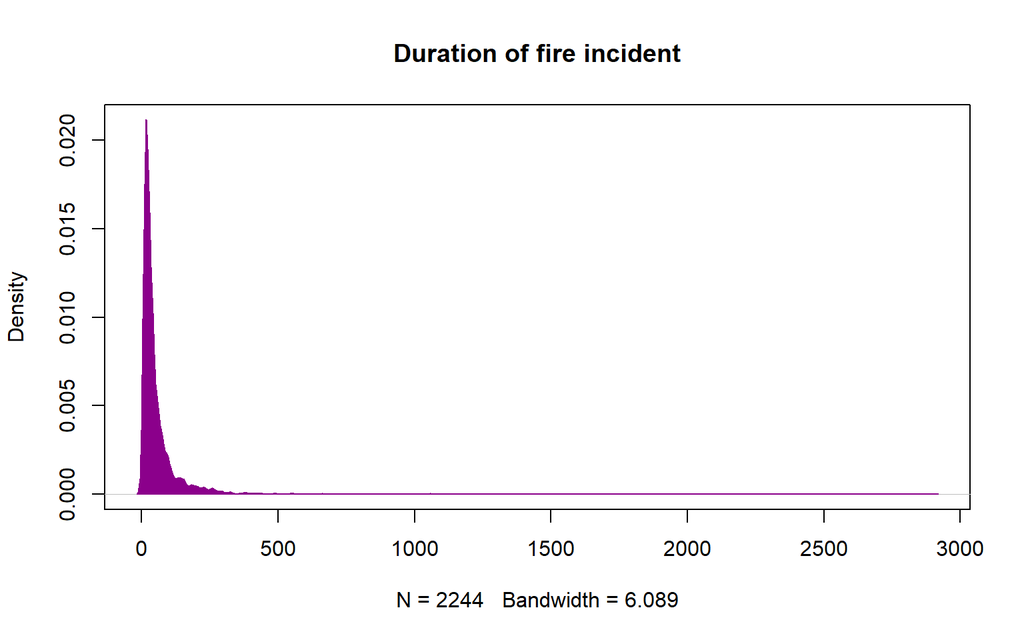

```r
d <- density(fires$IncidentDurationMinutes)
plot(d, main="Duration of fire incident")
polygon(d, col="darkmagenta", border="darkmagenta")
```

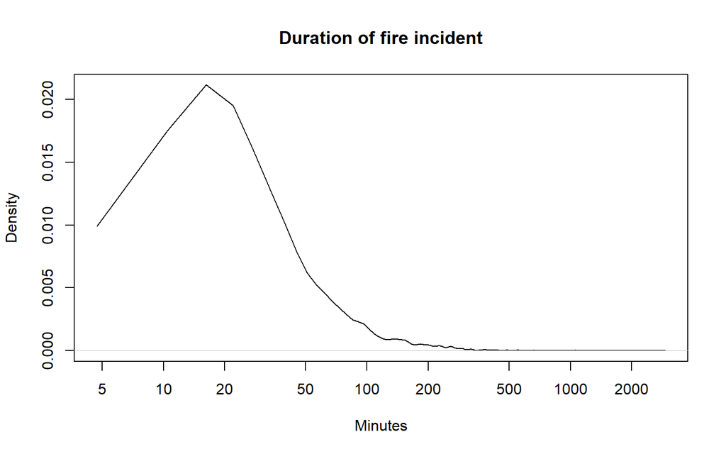

```r
d <- density(fires$IncidentDurationMinutes)
plot(d, main="Duration of fire incident",
     log="x",
     xlab="Minutes")
```

We then looked at a number of variables within our dataset (after data prep) that we thought might be useful for predicting incident length:

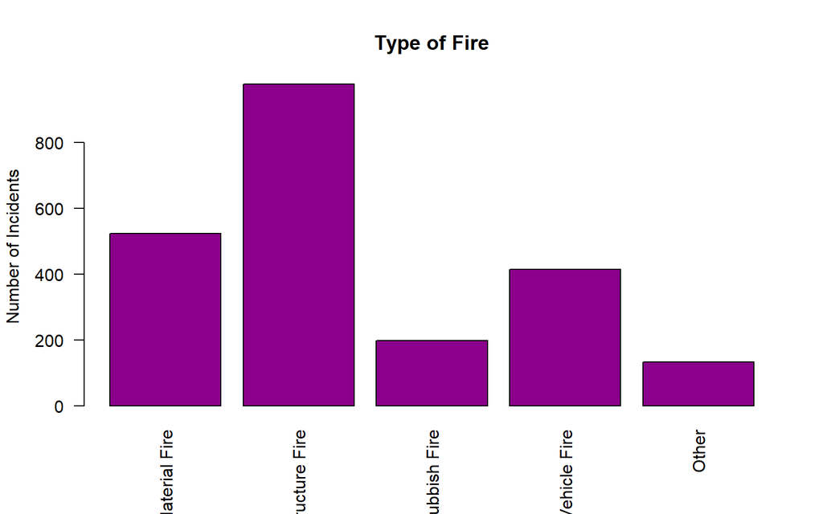

```r
barplot(table(fires$FireType),
        main="Type of Fire",
        ylab="Number of Incidents",
        col="darkmagenta",
        las=2)
```

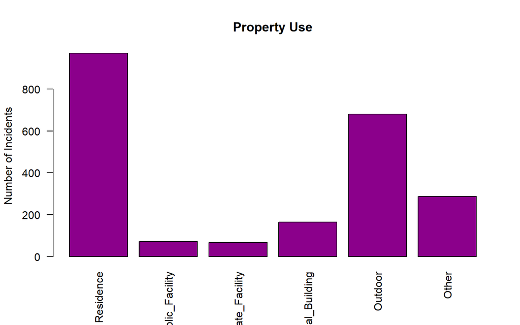

[figure not shown]

```r
barplot(table(fires$PropertyUse),
        main="Property Use",
        ylab="Number of Incidents",
        col="darkmagenta",
        las=2)
```

## Methods

We are interested in creating a regression model, and using NRMSE and R^2 as our primary evaluation metrics. Our aim is to create a model that predicts incident duration with reasonable accuracy, specifically, we want our model to be less than 20 minutes off after fine-tuning the model and adjusting its hyperparameter.

The maxdepth analysis and decision tree from our initial model are as follows:

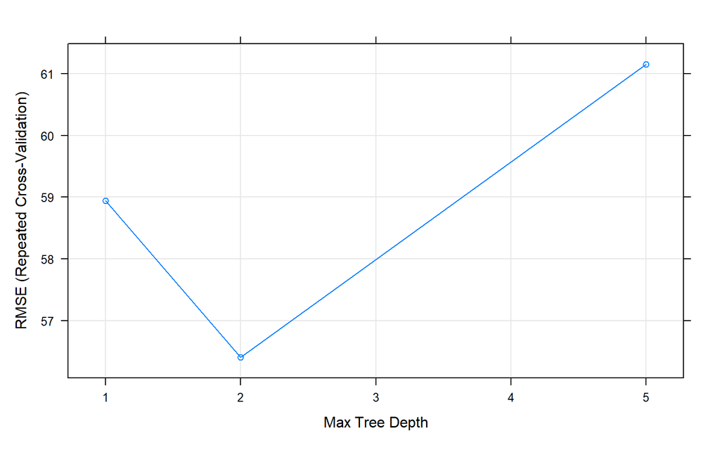

```r
plot(duration_model_dt)
```

A maximum depth of 2 clearly had the lowest RMSE, so it was chosen.

```r
varImp(duration_model_dt)
```

```
## rpart2 variable importance
##
##                              Overall
## PropertyLossDollars           100.00
## FireType                       25.99
## FireAreaOfOrigin               22.33
## PropertyUse                    18.43
## UnitFirstArrive                17.39
## Longitude                       0.00
## ZipCode                         0.00
## time                            0.00
## Latitude                        0.00
## season                          0.00
## UnitFirstResponseTimeMinutes    0.00
## Year                            0.00
## HeatSource                      0.00
## ItemFirstIgnited                0.00
## CauseOfIgnition                 0.00
```

Property Loss was by far the most important variable in the dataset, followed by Fire Type and Area of Origin.

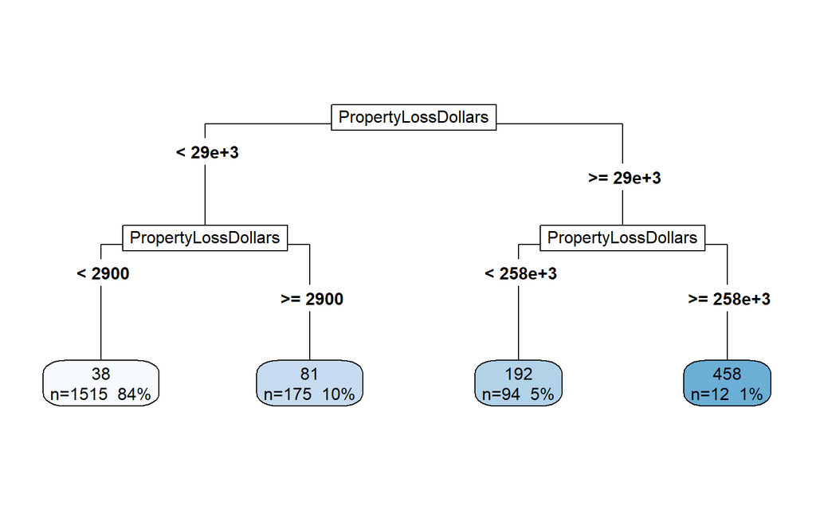

```r
rpart.plot(duration_model_dt$finalModel, type=5,extra=101)
```

This confirms that Property Loss was the most important variable.

The maxdepth analysis and decision tree from our tuned model are as follows:

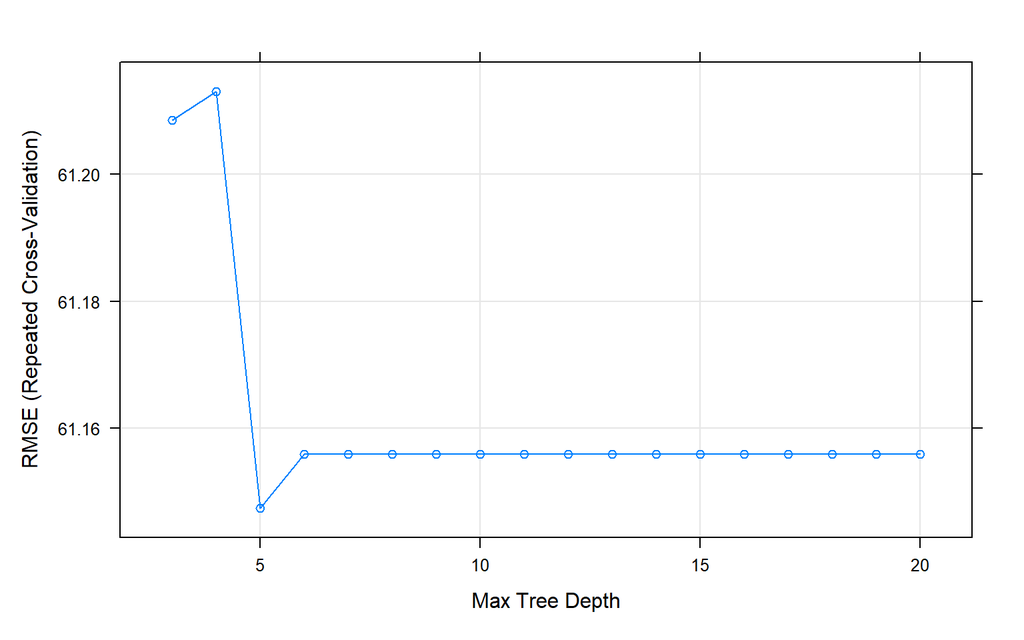

```r
plot(duration_model_dt_1)
```

This time, a maximum depth of 5 was chosen.

```r
varImp(duration_model_dt_1)
```

```
## rpart2 variable importance
##
##                              Overall
## PropertyLossDollars          100.000
## FireType                      38.349
## PropertyUse                   33.282
## FireAreaOfOrigin              23.000
## UnitFirstArrive               19.561
## Year                           5.106
## season                         4.925
## UnitFirstResponseTimeMinutes   4.189
## Latitude                       0.000
## HeatSource                     0.000
## CauseOfIgnition                0.000
## Longitude                      0.000
## ZipCode                        0.000
## ItemFirstIgnited               0.000
## time                           0.000
```

The variables of importance were largely unchanged.

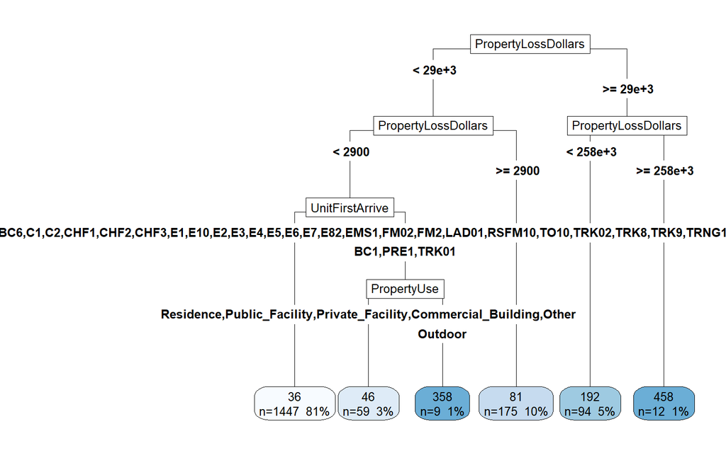

```r
rpart.plot(duration_model_dt_1$finalModel, type=5,extra=101)
```

The tree makes use of more variables now.

## Evaluation

### Original Model

```r
postResample(pred = grade_pred_reg, obs = tune$IncidentDurationMinutes)
```

```
##       RMSE   Rsquared        MAE
## 66.6179365  0.4116967 34.2423251
```

NRMSE:

```r
(duration_dt_rmse / (mean(tune$IncidentDurationMinutes)))
```

```
##    RMSE
## 1.13241
```

### Tuned model

```r
postResample(pred = grade_pred_reg, obs = tune$IncidentDurationMinutes)
```

```
##       RMSE   Rsquared        MAE
## 66.7182614  0.4105776 33.6007655
```

```r
(duration_dt_rmse_1 / (mean(tune$IncidentDurationMinutes)))
```

```
##     RMSE
## 1.134116
```

### Evaluating with the Tuned model on the Test set

```r
postResample(pred = grade_pred_reg, obs = test$IncidentDurationMinutes)
```

```
##        RMSE    Rsquared         MAE
## 102.9427188   0.3496291  35.1411255
```

```r
(duration_dt_rmse_1 / (mean(test$IncidentDurationMinutes)))
```

```
##     RMSE
## 1.762515
```

Our final predictions had an NRMSE of 176.2% and an r^2 value of 0.35 .

## Fairness Assessment

We do not necessarily have any protected classes, but it could be could to consider that our dataset did not contain any fires that 911 was not called for. It is worth noting that the results of our model will only be applicable to the Charlottesville area. If someone wanted to use our model in another location, they would need to train it using local data at that location.

## Limitations and Future Work

One of the limitations is our limited sample size. The dataset had a little over 2000 samples which can be hard to draw solid conclusions from as the model has limited previous values to use in order to help make future predictions. Our data also contained at least one NA per every row, and that really limited the possibilities. Our dataset may also have lacked certain features that would have been helpful in predicting incident duration.